# association_rules

## 2. Reglas de Asociación

Se aplica el algoritmo **Apriori** para descubrir patrones no evidentes en las películas del dataset de CineVision Studios. Las variables numéricas se discretizan en categorías significativas antes de aplicar el algoritmo.

**Variables utilizadas:**

- `budget` → budget_zero / budget_low / budget_medium / budget_high
- `revenue` → revenue_zero / revenue_low / revenue_medium / revenue_high
- `voteAvg` → voteAvg_zero / voteAvg_low / voteAvg_medium / voteAvg_high
- `popularity` → popularity_low / popularity_medium / popularity_high (terciles)
- `runtime` → runtime_short (<80min) / runtime_medium (80-120min) / runtime_long (>120min)
- `releaseYear` → era_classic (<2000) / era_2000s / era_2010s / era_recent (>=2020)
- `originalLanguage` → lang_en / lang_es / lang_fr / lang_ja / lang_other
- `genres` → cada género como ítem binario (genre_Drama, genre_Action, etc.)
- `video` → has_video

**Variables excluidas:** id, title, originalTitle, director, actors, homePage, productionCompany, actorsCharacter — son identificadores únicos que no generan patrones generalizables.

```python
import warnings
import numpy as np
import pandas as pd
import matplotlib.pyplot as plt
import seaborn as sns
from itertools import combinations
from collections import defaultdict

warnings.filterwarnings('ignore')

df_movies = pd.read_csv('movies_2026.csv', encoding='utf-8', encoding_errors='ignore')
print(f'Dataset: {df_movies.shape[0]:,} películas, {df_movies.shape[1]} variables')
df_movies[['budget','revenue','voteAvg','popularity','runtime','releaseYear','genres','originalLanguage','video']].head(3)
```

```
Dataset: 19,883 películas, 28 variables
```

|  | budget | revenue | voteAvg | popularity | runtime | releaseYear | genres | originalLanguage | video |
| --- | --- | --- | --- | --- | --- | --- | --- | --- | --- |
| 0 | 0.0 | 0.0 | 0.0 | 0.0357 | 95 | 2026.0 | Drama\|Crime | fa | False |
| 1 | 0.0 | 0.0 | 0.0 | 0.0357 | 3 | 2026.0 | Animation | en | False |
| 2 | 0.0 | 0.0 | 0.0 | 0.0214 | 2 | 2026.0 | Animation | en | False |

### Discretización de variables

```python
df = df_movies.copy()

# ── Funciones de discretización ──
def disc_budget(x):
    if x == 0:       return 'budget_zero'
    elif x < 5e6:    return 'budget_low'
    elif x < 50e6:   return 'budget_medium'
    else:            return 'budget_high'

def disc_revenue(x):
    if x == 0:       return 'revenue_zero'
    elif x < 5e6:    return 'revenue_low'
    elif x < 100e6:  return 'revenue_medium'
    else:            return 'revenue_high'

def disc_vote(x):
    if x == 0:      return 'voteAvg_zero'
    elif x < 5:     return 'voteAvg_low'
    elif x <= 7:    return 'voteAvg_medium'
    else:           return 'voteAvg_high'

p33 = df['popularity'].quantile(0.33)
p66 = df['popularity'].quantile(0.66)
def disc_pop(x):
    if x <= p33:    return 'popularity_low'
    elif x <= p66:  return 'popularity_medium'
    else:           return 'popularity_high'

def disc_runtime(x):
    if x == 0:       return None
    elif x < 80:     return 'runtime_short'
    elif x <= 120:   return 'runtime_medium'
    else:            return 'runtime_long'

def disc_year(x):
    try: y = int(x)
    except: return None
    if y < 2000:   return 'era_classic'
    elif y < 2010: return 'era_2000s'
    elif y < 2020: return 'era_2010s'
    else:          return 'era_recent'

def disc_lang(x):
    if x == 'en': return 'lang_en'
    elif x == 'es': return 'lang_es'
    elif x == 'fr': return 'lang_fr'
    elif x == 'ja': return 'lang_ja'
    else:           return 'lang_other'

df['disc_budget']  = df['budget'].apply(disc_budget)
df['disc_revenue'] = df['revenue'].apply(disc_revenue)
df['disc_vote']    = df['voteAvg'].apply(disc_vote)
df['disc_pop']     = df['popularity'].apply(disc_pop)
df['disc_runtime'] = df['runtime'].apply(disc_runtime)
df['disc_year']    = df['releaseYear'].apply(disc_year)
df['disc_lang']    = df['originalLanguage'].apply(disc_lang)
df['disc_video']   = df['video'].apply(lambda x: 'has_video' if str(x) in ['True','1','true'] else None)

# ── Géneros (one-hot) ──
genre_series = df['genres'].dropna().str.split('|')
all_genres = sorted(set(g.strip() for sublist in genre_series for g in sublist if g.strip()))
print(f'{len(all_genres)} géneros encontrados: {all_genres}')
for genre in all_genres:
    df[f'genre_{genre}'] = df['genres'].apply(
        lambda x: f'genre_{genre}' if pd.notna(x) and genre in x else None
    )
```

```
19 géneros encontrados: ['Action', 'Adventure', 'Animation', 'Comedy', 'Crime', 'Documentary', 'Drama', 'Family', 'Fantasy', 'History', 'Horror', 'Music', 'Mystery', 'Romance', 'Science Fiction', 'TV Movie', 'Thriller', 'War', 'Western']
```

```python
# ── Construir transacciones ──
disc_cols = ['disc_budget','disc_revenue','disc_vote','disc_pop','disc_runtime',
             'disc_year','disc_lang','disc_video'] + [f'genre_{g}' for g in all_genres]

transactions = [
    frozenset(v for v in row if pd.notna(v) and v is not None)
    for _, row in df[disc_cols].iterrows()
]
transactions = [t for t in transactions if len(t) > 0]
print(f'Total transacciones: {len(transactions):,}')
```

```
Total transacciones: 19,883
```

### Análisis de frecuencia de ítems

Antes de ejecutar Apriori, se analiza la frecuencia de cada ítem para identificar aquellos demasiado frecuentes (>50%) que podrían generar reglas triviales y poco accionables.

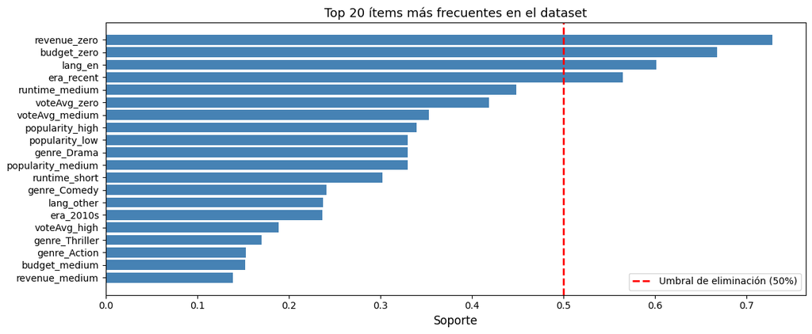

```
Ítems con soporte > 50%:
            item   support
0   revenue_zero  0.728512
1    budget_zero  0.667958
10       lang_en  0.601569
5     era_recent  0.565307
```

```python
item_freq = defaultdict(int)
for t in transactions:
    for item in t: item_freq[item] += 1
n = len(transactions)
freq_df = pd.DataFrame([(k, v/n) for k,v in item_freq.items()], columns=['item','support'])
freq_df = freq_df.sort_values('support', ascending=False)

fig, ax = plt.subplots(figsize=(12, 5))
top20 = freq_df.head(20)
bars = ax.barh(top20['item'][::-1], top20['support'][::-1], color='steelblue')
ax.axvline(0.5, color='red', linestyle='--', linewidth=2, label='Umbral de eliminación (50%)')
ax.set_xlabel('Soporte', fontsize=12)
ax.set_title('Top 20 ítems más frecuentes en el dataset', fontsize=13)
ax.legend()
plt.tight_layout()
plt.show()

print('Ítems con soporte > 50%:')
print(freq_df[freq_df['support'] > 0.50][['item','support']].to_string())
```

Los ítems `revenue_zero`, `budget_zero`, `lang_en` y `era_recent` aparecen en más del 50% de las transacciones. Esto genera reglas triviales como "si película con presupuesto cero → tiene revenue cero", que no aportan insight de negocio. Se decide eliminarlos para el **Experimento 3**, que será el más informativo.

### Implementación del algoritmo Apriori

```python
def apriori(transactions, min_support=0.05, min_confidence=0.5, max_len=3):
    """
    Implementación del algoritmo Apriori.
    Parámetros:
        min_support: fracción mínima de transacciones que deben contener el itemset
        min_confidence: confianza mínima para generar una regla A → B
        max_len: tamaño máximo de los itemsets a explorar
    """
    n = len(transactions)

    # Paso 1: contar ítems individuales
    item_counts = defaultdict(int)
    for t in transactions:
        for item in t: item_counts[frozenset([item])] += 1

    freq_sets = {k: v/n for k,v in item_counts.items() if v/n >= min_support}
    all_freq = dict(freq_sets)
    current_sets = list(freq_sets.keys())
    k = 2

    # Paso 2: generar itemsets de tamaño k
    while current_sets and k <= max_len:
        candidates = defaultdict(int)
        items_list = sorted(set(i for s in current_sets for i in s))
        for combo in combinations(items_list, k):
            candidate = frozenset(combo)
            if all(frozenset(sub) in all_freq for sub in combinations(combo, k-1)):
                for t in transactions:
                    if candidate.issubset(t): candidates[candidate] += 1
        new_freq = {ks: cnt/n for ks,cnt in candidates.items() if cnt/n >= min_support}
        all_freq.update(new_freq)
        current_sets = list(new_freq.keys())
        k += 1

    # Paso 3: generar reglas
    rules = []
    for itemset, support in all_freq.items():
        if len(itemset) < 2: continue
        for i in range(1, len(itemset)):
            for ant in combinations(itemset, i):
                ant = frozenset(ant)
                con = itemset - ant
                ant_sup = all_freq.get(ant, 0)
                if ant_sup == 0: continue
                conf = support / ant_sup
                if conf >= min_confidence:
                    lift = conf / all_freq.get(con, support)
                    rules.append({
                        'antecedents': ant, 'consequents': con,
                        'support': round(support,4),
                        'confidence': round(conf,4),
                        'lift': round(lift,4)
                    })

    if not rules: return pd.DataFrame()
    return pd.DataFrame(rules).sort_values('lift', ascending=False)

print('Algoritmo Apriori listo.')
```

```
Algoritmo Apriori listo.
```

### Experimento 1: Soporte moderado, confianza alta

**min_support = 0.10 | min_confidence = 0.70**

Buscamos reglas que aparezcan en al menos el 10% de las películas con alta certeza. Esto captura patrones muy generales.

```python
rules_1 = apriori(transactions, min_support=0.10, min_confidence=0.70, max_len=3)
rules_1['antecedents_str'] = rules_1['antecedents'].apply(lambda x: ', '.join(sorted(x)))
rules_1['consequents_str'] = rules_1['consequents'].apply(lambda x: ', '.join(sorted(x)))
print(f'Reglas generadas: {len(rules_1)}')
rules_1[['antecedents_str','consequents_str','support','confidence','lift']].head(15)
```

```
Reglas generadas: 204
```

|  | antecedents_str | consequents_str | support | confidence | lift |
| --- | --- | --- | --- | --- | --- |
| 172 | lang_en, popularity_low | runtime_short | 0.1135 | 0.8201 | 2.7133 |
| 181 | lang_en, voteAvg_zero | runtime_short | 0.1311 | 0.7429 | 2.4577 |
| 196 | runtime_short, voteAvg_zero | popularity_low | 0.1804 | 0.7887 | 2.3894 |
| 144 | era_recent, runtime_short | popularity_low | 0.1957 | 0.7412 | 2.2455 |
| 185 | lang_other, popularity_low | voteAvg_zero | 0.1156 | 0.9251 | 2.2092 |
| 97 | budget_zero, popularity_low | voteAvg_zero | 0.2605 | 0.9225 | 2.2030 |
| 197 | popularity_low, runtime_short | voteAvg_zero | 0.1804 | 0.9214 | 2.2004 |
| 191 | voteAvg_zero | popularity_low, revenue_zero | 0.2979 | 0.7115 | 2.1889 |
| 194 | popularity_low, revenue_zero | voteAvg_zero | 0.2979 | 0.9166 | 2.1889 |
| 95 | popularity_low | budget_zero, voteAvg_zero | 0.2605 | 0.7891 | 2.1874 |
| 96 | budget_zero, voteAvg_zero | popularity_low | 0.2605 | 0.7220 | 2.1874 |
| 33 | popularity_low | voteAvg_zero | 0.3018 | 0.9142 | 2.1832 |
| 32 | voteAvg_zero | popularity_low | 0.3018 | 0.7206 | 2.1832 |
| 150 | era_recent, popularity_low | voteAvg_zero | 0.3017 | 0.9142 | 2.1831 |
| 146 | voteAvg_zero | era_recent, popularity_low | 0.3017 | 0.7204 | 2.1831 |

### Experimento 2: Soporte bajo, confianza media

**min_support = 0.05 | min_confidence = 0.60**

Al reducir el soporte mínimo exploramos patrones más específicos que aplican a nichos de películas.

```python
rules_2 = apriori(transactions, min_support=0.05, min_confidence=0.60, max_len=3)
rules_2['antecedents_str'] = rules_2['antecedents'].apply(lambda x: ', '.join(sorted(x)))
rules_2['consequents_str'] = rules_2['consequents'].apply(lambda x: ', '.join(sorted(x)))
print(f'Reglas generadas: {len(rules_2)}')
rules_2[['antecedents_str','consequents_str','support','confidence','lift']].head(15)
```

```
Reglas generadas: 531
```

|  | antecedents_str | consequents_str | support | confidence | lift |
| --- | --- | --- | --- | --- | --- |
| 130 | revenue_medium, voteAvg_medium | budget_medium | 0.0626 | 0.6805 | 4.4524 |
| 113 | lang_en, revenue_medium | budget_medium | 0.0802 | 0.6731 | 4.4041 |
| 127 | revenue_medium, runtime_medium | budget_medium | 0.0703 | 0.6517 | 4.2641 |
| 122 | popularity_high, revenue_medium | budget_medium | 0.0594 | 0.6387 | 4.1789 |
| 7 | revenue_medium | budget_medium | 0.0888 | 0.6374 | 4.1704 |
| 449 | revenue_high | lang_en, popularity_high | 0.0697 | 0.9058 | 3.4306 |
| 98 | budget_high | lang_en, popularity_high | 0.0553 | 0.8813 | 3.3378 |
| 450 | lang_en, revenue_high | popularity_high | 0.0697 | 0.9409 | 2.7674 |
| 81 | revenue_high | popularity_high | 0.0721 | 0.9372 | 2.7566 |
| 464 | lang_en, popularity_low | runtime_short | 0.1135 | 0.8201 | 2.7133 |
| 99 | budget_high, lang_en | popularity_high | 0.0553 | 0.8971 | 2.6387 |
| 1 | budget_high | popularity_high | 0.0560 | 0.8933 | 2.6276 |
| 486 | lang_en, voteAvg_zero | runtime_short | 0.1311 | 0.7429 | 2.4577 |
| 517 | runtime_short, voteAvg_zero | popularity_low | 0.1804 | 0.7887 | 2.3894 |
| 274 | era_2010s, genre_Action | popularity_high | 0.0515 | 0.8055 | 2.3692 |

### Experimento 3: Sin ítems muy frecuentes (más informativo)

**min_support = 0.05 | min_confidence = 0.55**

Se eliminan `revenue_zero`, `budget_zero`, `lang_en` y `era_recent` por aparecer en más del 50% de películas, lo que distorsiona las reglas. Este experimento revela patrones accionables para CineVision Studios.

```python
items_to_remove = set(freq_df[freq_df['support'] > 0.50]['item'].tolist())
print(f'Eliminando ítems triviales: {items_to_remove}\n')

transactions_filtered = [
    frozenset(i for i in t if i not in items_to_remove)
    for t in transactions
]
transactions_filtered = [t for t in transactions_filtered if len(t) >= 2]
print(f'Transacciones con datos no triviales: {len(transactions_filtered):,}')
```

```
Eliminando ítems triviales: {'budget_zero', 'revenue_zero', 'lang_en', 'era_recent'}

Transacciones con datos no triviales: 19,883
```

```python
rules_3 = apriori(transactions_filtered, min_support=0.05, min_confidence=0.55, max_len=3)
rules_3['antecedents_str'] = rules_3['antecedents'].apply(lambda x: ', '.join(sorted(x)))
rules_3['consequents_str'] = rules_3['consequents'].apply(lambda x: ', '.join(sorted(x)))
print(f'Reglas generadas: {len(rules_3)}')
rules_3[['antecedents_str','consequents_str','support','confidence','lift']].head(20)
```

```
Reglas generadas: 143
```

|  | antecedents_str | consequents_str | support | confidence | lift |
| --- | --- | --- | --- | --- | --- |
| 63 | revenue_medium, voteAvg_medium | budget_medium | 0.0626 | 0.6805 | 4.4524 |
| 59 | revenue_medium, runtime_medium | budget_medium | 0.0703 | 0.6517 | 4.2641 |
| 58 | budget_medium, runtime_medium | revenue_medium | 0.0703 | 0.5894 | 4.2321 |
| 62 | budget_medium, voteAvg_medium | revenue_medium | 0.0626 | 0.5882 | 4.2235 |
| 53 | popularity_high, revenue_medium | budget_medium | 0.0594 | 0.6387 | 4.1789 |
| 3 | revenue_medium | budget_medium | 0.0888 | 0.6374 | 4.1704 |
| 2 | budget_medium | revenue_medium | 0.0888 | 0.5808 | 4.1704 |
| 52 | budget_medium, popularity_high | revenue_medium | 0.0594 | 0.5683 | 4.0810 |
| 34 | revenue_high | popularity_high | 0.0721 | 0.9372 | 2.7566 |
| 0 | budget_high | popularity_high | 0.0560 | 0.8933 | 2.6276 |
| 135 | runtime_short, voteAvg_zero | popularity_low | 0.1804 | 0.7887 | 2.3894 |
| 71 | era_2010s, genre_Action | popularity_high | 0.0515 | 0.8055 | 2.3692 |
| 100 | genre_Documentary, voteAvg_zero | popularity_low | 0.0716 | 0.7664 | 2.3219 |
| 121 | lang_other, runtime_short | popularity_low | 0.0580 | 0.7382 | 2.2363 |
| 123 | lang_other, popularity_low | voteAvg_zero | 0.1156 | 0.9251 | 2.2092 |
| 137 | popularity_low, runtime_short | voteAvg_zero | 0.1804 | 0.9214 | 2.2004 |
| 101 | genre_Documentary, popularity_low | voteAvg_zero | 0.0716 | 0.9205 | 2.1982 |
| 64 | budget_medium | runtime_medium, voteAvg_medium | 0.0913 | 0.5972 | 2.1942 |
| 44 | popularity_low | voteAvg_zero | 0.3018 | 0.9142 | 2.1832 |
| 43 | voteAvg_zero | popularity_low | 0.3018 | 0.7206 | 2.1832 |

### Visualización de reglas

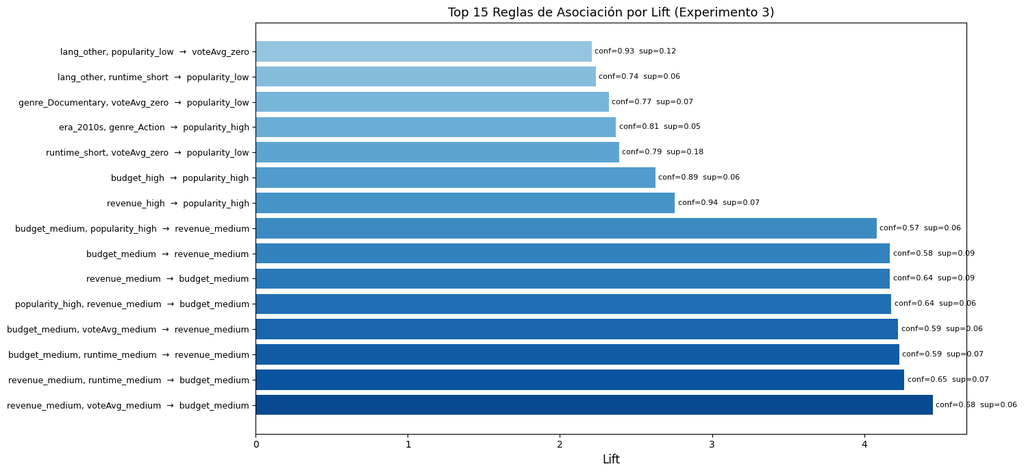

```python
# Top 15 reglas por Lift
top_rules = rules_3.head(15).copy()
top_rules['rule'] = top_rules['antecedents_str'] + '  →  ' + top_rules['consequents_str']

fig, ax = plt.subplots(figsize=(15, 7))
colors = plt.cm.Blues(np.linspace(0.4, 0.9, len(top_rules)))
bars = ax.barh(range(len(top_rules)), top_rules['lift'].values, color=colors[::-1])
ax.set_yticks(range(len(top_rules)))
ax.set_yticklabels(top_rules['rule'].values, fontsize=9)
ax.set_xlabel('Lift', fontsize=12)
ax.set_title('Top 15 Reglas de Asociación por Lift (Experimento 3)', fontsize=13)
for i, (bar, row) in enumerate(zip(bars, top_rules.itertuples())):
    ax.text(bar.get_width()+0.02, i, f'conf={row.confidence:.2f}  sup={row.support:.2f}', va='center', fontsize=8)
plt.tight_layout()
plt.show()
```

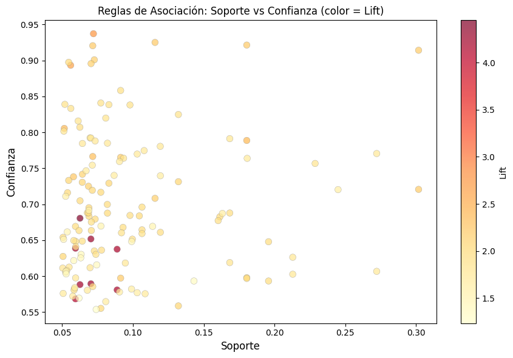

```python
# Scatter: Soporte vs Confianza coloreado por Lift
fig, ax = plt.subplots(figsize=(9, 6))
sc = ax.scatter(rules_3['support'], rules_3['confidence'],
                c=rules_3['lift'], cmap='YlOrRd', alpha=0.7, s=60, edgecolors='gray', linewidths=0.3)
plt.colorbar(sc, label='Lift')
ax.set_xlabel('Soporte', fontsize=12)
ax.set_ylabel('Confianza', fontsize=12)
ax.set_title('Reglas de Asociación: Soporte vs Confianza (color = Lift)', fontsize=12)
plt.tight_layout()
plt.show()
```

### Reglas más interesantes por categoría

```python
# Presupuesto/Revenue
print('=== Reglas relacionadas con presupuesto y revenue ===')
commercial = rules_3[
    rules_3['antecedents_str'].str.contains('budget_|revenue_') |
    rules_3['consequents_str'].str.contains('budget_|revenue_')
].head(10)
print(commercial[['antecedents_str','consequents_str','support','confidence','lift']].to_string())

print('\n=== Reglas relacionadas con géneros ===')
genre_rules = rules_3[
    rules_3['antecedents_str'].str.contains('genre_') |
    rules_3['consequents_str'].str.contains('genre_')
].head(10)
print(genre_rules[['antecedents_str','consequents_str','support','confidence','lift']].to_string())

print('\n=== Reglas relacionadas con calificación y popularidad ===')
quality = rules_3[
    rules_3['antecedents_str'].str.contains('voteAvg_high|popularity_high') |
    rules_3['consequents_str'].str.contains('voteAvg_high|popularity_high')
].head(10)
print(quality[['antecedents_str','consequents_str','support','confidence','lift']].to_string())
```

```
=== Reglas relacionadas con presupuesto y revenue ===
                    antecedents_str  consequents_str  support  confidence    lift
63   revenue_medium, voteAvg_medium    budget_medium   0.0626      0.6805  4.4524
59   revenue_medium, runtime_medium    budget_medium   0.0703      0.6517  4.2641
58    budget_medium, runtime_medium   revenue_medium   0.0703      0.5894  4.2321
62    budget_medium, voteAvg_medium   revenue_medium   0.0626      0.5882  4.2235
53  popularity_high, revenue_medium    budget_medium   0.0594      0.6387  4.1789
3                    revenue_medium    budget_medium   0.0888      0.6374  4.1704
2                     budget_medium   revenue_medium   0.0888      0.5808  4.1704
52   budget_medium, popularity_high   revenue_medium   0.0594      0.5683  4.0810
34                     revenue_high  popularity_high   0.0721      0.9372  2.7566
0                       budget_high  popularity_high   0.0560      0.8933  2.6276

=== Reglas relacionadas con géneros ===
                       antecedents_str  consequents_str  support  confidence    lift
```

[output cut: 23 more lines]

### Conclusiones de Reglas de Asociación

Se aplicó el algoritmo Apriori con tres configuraciones distintas de parámetros:

**Experimento 1** (support≥0.10, confidence≥0.70): Se generaron 204 reglas con alta confianza pero dominadas por ítems muy frecuentes, resultando en reglas triviales como `budget_zero → revenue_zero`.

**Experimento 2** (support≥0.05, confidence≥0.60): 531 reglas. Mayor diversidad de patrones pero aún contaminadas por los ítems omnipresentes.

**Experimento 3** (sin ítems >50%, support≥0.05, confidence≥0.55): 143 reglas accionables. Las más relevantes para CineVision Studios:

1. **Inversión y retorno** (lift ~4.2–4.5): `budget_medium + runtime_medium → revenue_medium` y `revenue_medium → budget_medium`. Películas con presupuesto medio (5–50M) y duración estándar tienen alta probabilidad de generar ingresos medios. Esto confirma que la inversión moderada con duración apropiada es un perfil de bajo riesgo.
2. **Blockbusters** (lift ~2.6–2.8): `budget_high → popularity_high` (conf=0.89) y `revenue_high → popularity_high` (conf=0.94). Las películas con mayor inversión casi siempre resultan en alta popularidad en TMDB, lo cual se correlaciona con mayor exposición y marketing.
3. **Películas de acción recientes** (lift ~2.4): `era_2010s + genre_Action → popularity_high`. Las películas de acción de la última década tienen alta probabilidad de ser populares, sugiriendo que este género sigue siendo relevante para el mercado actual.
4. **Patrón de baja calidad** (lift ~2.2–2.4): `runtime_short + voteAvg_zero → popularity_low`. Películas cortas sin calificaciones tienden a baja popularidad, representando el segmento de producciones sin distribución significativa.